# Single-cell RNA sequencing ~ Session 2

Rockefeller University, Bioinformatics Resource Centre

https://rockefelleruniversity.github.io/scRNA-seq/

## Data analysis with [Seurat](https://satijalab.org/seurat/)

[Seurat](https://satijalab.org/seurat/) is a powerful package for single-cell data analysis. It supports many common analysis of single-cell RNAseq and cross connection with many useful packages through [SeuratWrapper](https://github.com/satijalab/seurat-wrappers).

In this session, we will demonstrate our regular workflow for single-cell RNAseq data analysis with Seurat.

## Outline

- Read Cell Ranger results into Seurat object
- Generate QC
- Evaluate cell cycle
- Normalize data and do clustering
- Marker genes for each cluster
- Advanced visualization

# Create Seurat object and Generare QC plots

## Cell Ranger counting matrix

- The data is available on [DropBox](https://www.dropbox.com/sh/ztu0pucvu21szxm/AABGUhTryKp1T1CsoEUFRPcwa?dl=0)

```r
tar_dir <- "~/path/to/raw/data"
```

## Load Cell Ranger results into Seurat

- Loading data
- Estimate mitochondrial contents

```r
library(Seurat)
samID <- "CTRL"
X10_file <- Seurat::Read10X(tar_dir)
obj <- CreateSeuratObject(counts = X10_file, project = samID, min.cells = 5, min.features = 200)
obj$dset <- samID
obj <- Seurat::RenameCells(obj, add.cell.id = samID)
#
obj[["percent.mt"]] <- PercentageFeatureSet(obj, pattern = "^mt-")
```

## Subset dataset

We have a small subset version of this dataset that you can load in from the *data/* directory to try this out.

## Cell information

The object metadata contains cell barcode, mitochondrial contents, datasets, and clustering etc

```r
head(obj@meta.data)
```

```
##                         orig.ident nCount_RNA nFeature_RNA dset percent.mt
## CTRL_CACTCCATCTTATCTG-1       CTRL       7748         2372 CTRL   5.201342
## CTRL_CCTCTGACAGTAGAGC-1       CTRL       9301         2715 CTRL   5.053220
## CTRL_GACGTTAGTAGAAGGA-1       CTRL       8213         2412 CTRL   4.699866
## CTRL_TGATTTCCAGCCTGTG-1       CTRL       8363         2308 CTRL   5.177568
## CTRL_ATCGAGTCAATCTGCA-1       CTRL       3392         1303 CTRL  20.725236
## CTRL_TGACTTTTCACCGGGT-1       CTRL       7034         2166 CTRL   7.094114
```

## Raw count matrix

```r
head(obj@assays$RNA@counts)
```

```
## 6 x 1000 sparse Matrix of class "dgCMatrix"
```

```
##    [[ suppressing 1000 column names 'CTRL_CACTCCATCTTATCTG-1', 'CTRL_CCTCTGACAGTAGAGC-1', 'CTRL_GACGTTAGTAGAAGGA-1' ... ]]
```

[output not shown]

[output cut: 141 more lines]

[output not shown]

## Scaled or normalized data

```r
head(obj@assays$RNA@data)
```

```
## 6 x 1000 sparse Matrix of class "dgCMatrix"
```

```
##    [[ suppressing 1000 column names 'CTRL_CACTCCATCTTATCTG-1', 'CTRL_CCTCTGACAGTAGAGC-1', 'CTRL_GACGTTAGTAGAAGGA-1' ... ]]
```

[output not shown]

[output cut: 701 more lines]

[output not shown]

## Evaluate data

Seurat has in-built functions to easily compare features. - read counts: nCount_RNA - gene counts: nFeature_RNA - mitochondrial content: percent.mt

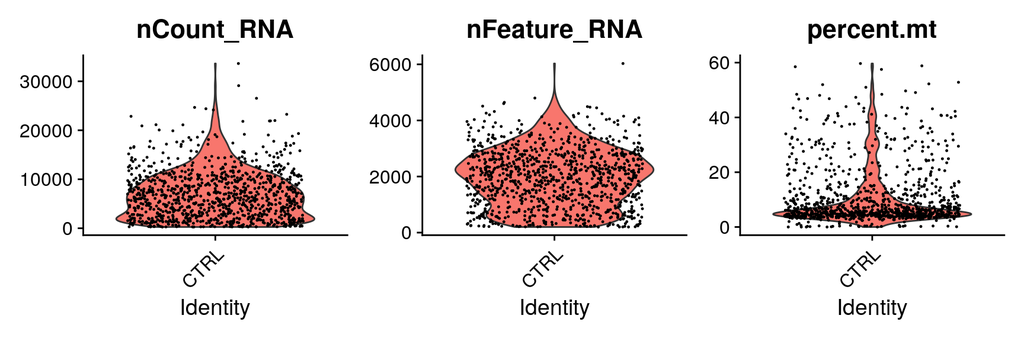

```r
VlnPlot(obj, features = c("nCount_RNA", "nFeature_RNA", "percent.mt"), pt.size = 0.2)
```

## Read counts vs genes counts

*FeatureScatter* allows pairwise comparisons of features, like counts…

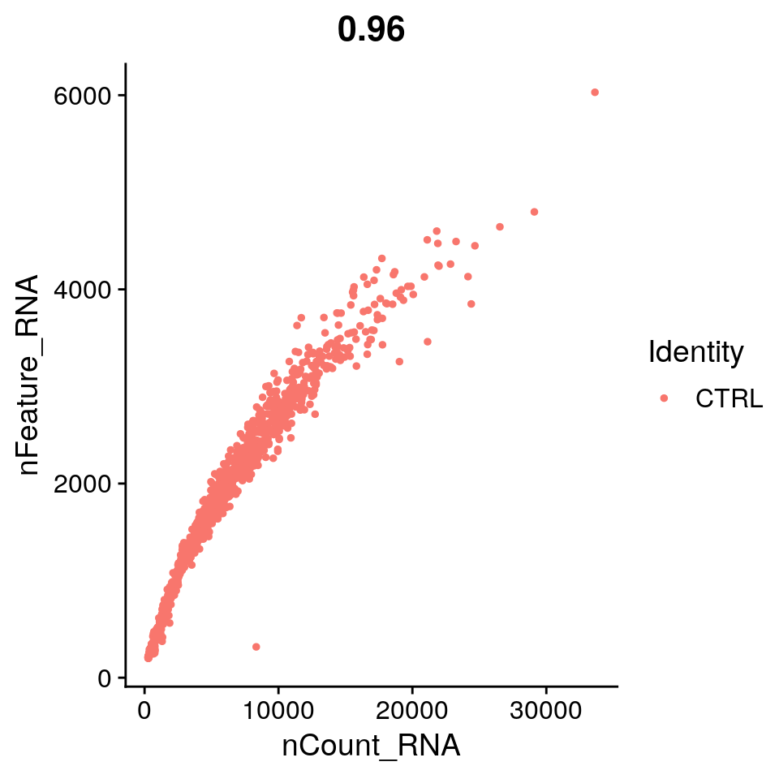

```r
FeatureScatter(obj, feature1 = "nCount_RNA", feature2 = "nFeature_RNA")
```

## Read counts vs mitochondrial content

…or mitochondiral content.

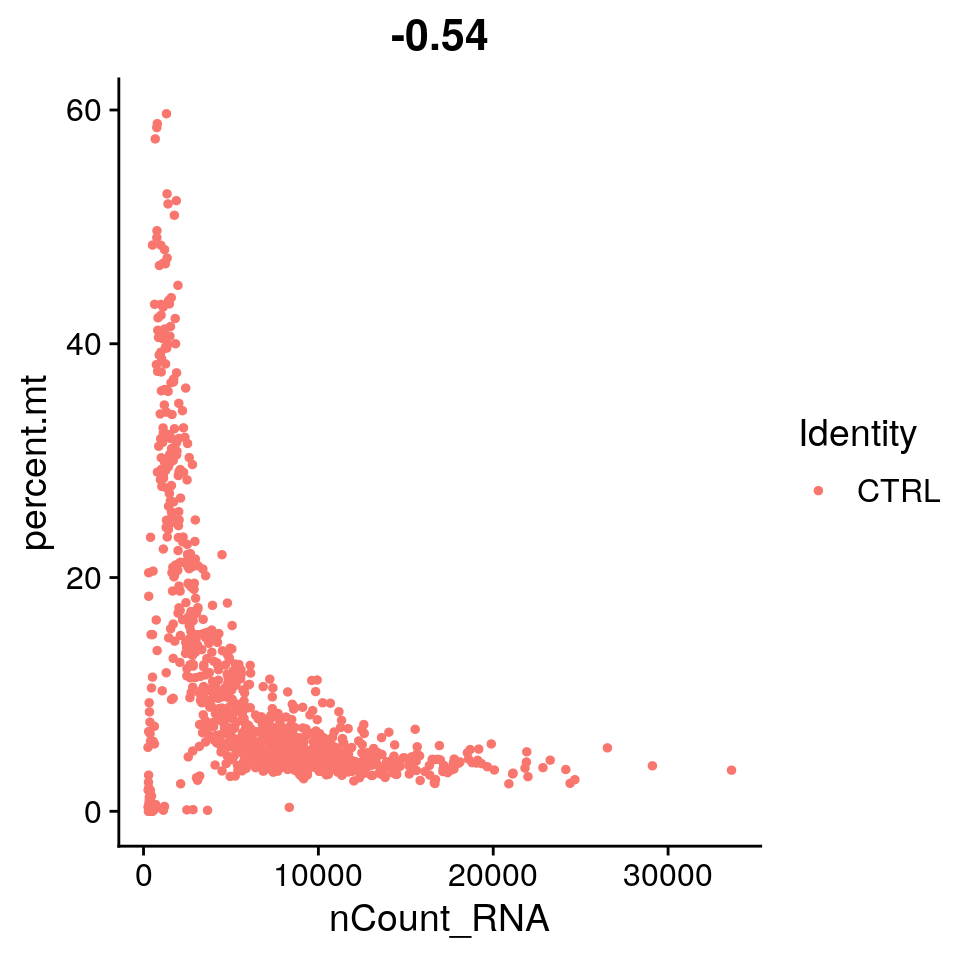

```r
FeatureScatter(obj, feature1 = "nCount_RNA", feature2 = "percent.mt")
```

## Remove potential cell debris

- High mitochondrial content and low read counts can be filtered out.

```r
summary(obj@meta.data$percent.mt)
```

```
##    Min. 1st Qu.  Median    Mean 3rd Qu.    Max.
##   0.000   4.249   5.986  10.804  12.428  59.680
```

```r
mt_cutH <- 10
obj_unfiltered <- obj
obj <- subset(obj, subset = percent.mt < mt_cutH)
```

## Remove potential cell debris

Unfiltered

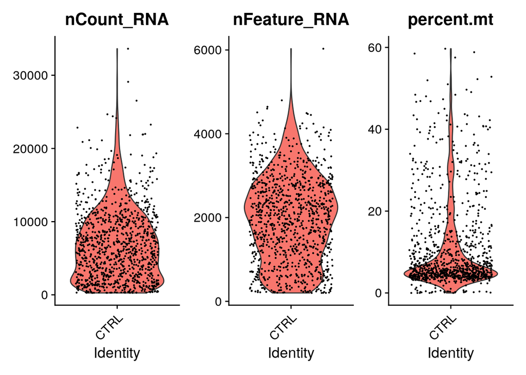

```r
VlnPlot(obj_unfiltered, features = c("nCount_RNA", "nFeature_RNA", "percent.mt"),
    pt.size = 0.2)
```

Filtered

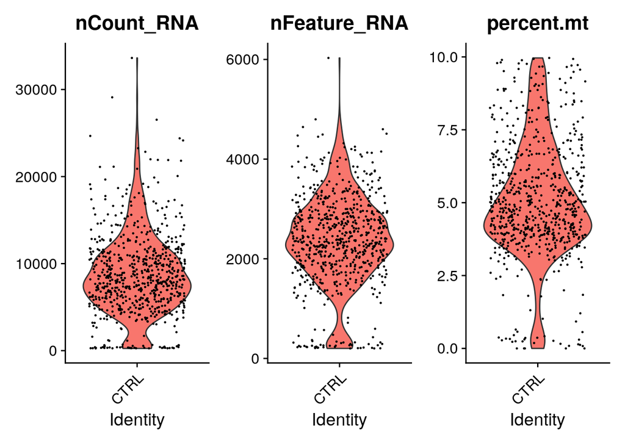

```r
VlnPlot(obj, features = c("nCount_RNA", "nFeature_RNA", "percent.mt"), pt.size = 0.2)
```

## Remove potential cell debris

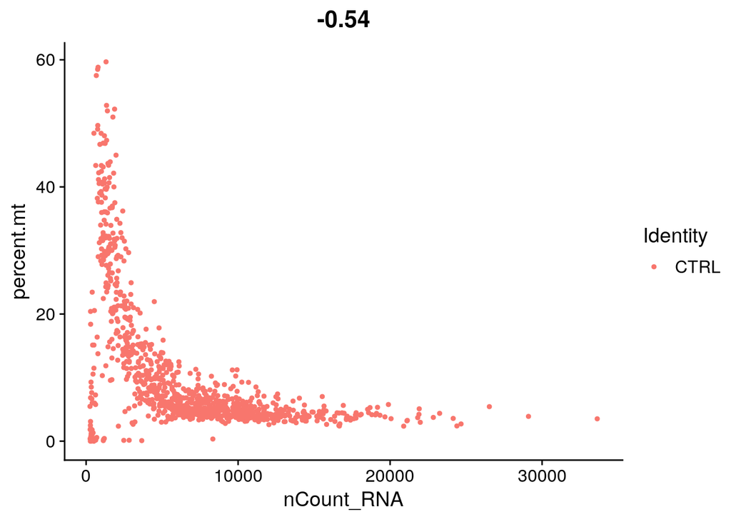

```r
FeatureScatter(obj_unfiltered, feature1 = "nCount_RNA", feature2 = "percent.mt")
```

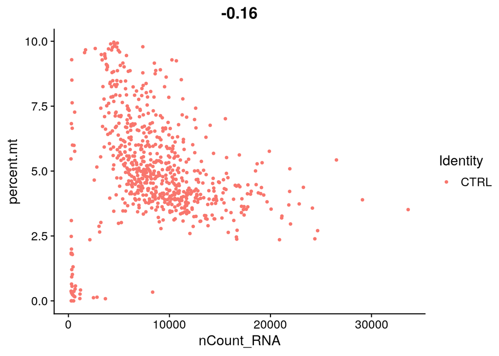

```r
FeatureScatter(obj, feature1 = "nCount_RNA", feature2 = "percent.mt")
```

# Cell cycle phase determination

## Cell cycle ~ covert gene list

- In Seurat, the default marker genes for S phase and G2/M phase are stored in *cc.gene* list
- This list is based on human data.
- We can convert it into mouse gene symbol by using *bioMart*

```r
convertHumanGeneList <- function(x) {
    require("biomaRt")
    human = useMart("ensembl", dataset = "hsapiens_gene_ensembl", host = "http://useast.ensembl.org")
    mouse = useMart("ensembl", dataset = "mmusculus_gene_ensembl", host = "http://useast.ensembl.org")
    genesV2 = getLDS(attributes = c("hgnc_symbol"), filters = "hgnc_symbol", values = x,
        mart = human, attributesL = c("mgi_symbol"), martL = mouse, uniqueRows = T)
    humanx <- unique(genesV2[, 2])
    return(humanx)
}
#
s_gene <- convertHumanGeneList(cc.genes$s.genes)
g2m_gene <- convertHumanGeneList(cc.genes$g2m.genes)
```

## Cell cycle ~ estimation

```r
obj <- CellCycleScoring(obj, s.features = s_gene, g2m.features = g2m_gene, set.ident = TRUE)
obj@meta.data[1:2, ]
```

```
##                         orig.ident nCount_RNA nFeature_RNA dset percent.mt
## CTRL_CACTCCATCTTATCTG-1       CTRL       7748         2372 CTRL   5.201342
## CTRL_CCTCTGACAGTAGAGC-1       CTRL       9301         2715 CTRL   5.053220
##                            S.Score G2M.Score Phase old.ident
## CTRL_CACTCCATCTTATCTG-1 -0.2260109 0.2533774   G2M      CTRL
## CTRL_CCTCTGACAGTAGAGC-1 -0.1392145 0.4500886   G2M      CTRL
```

## Cell cycle ~ phase

```r
yd_dat <- as.data.frame(table(obj@meta.data$dset, obj@meta.data$Phase))
head(yd_dat)
```

```
##   Var1 Var2 Freq
## 1 CTRL   G1  246
## 2 CTRL  G2M  214
## 3 CTRL    S  232
```

## Cell cycle ~ phase

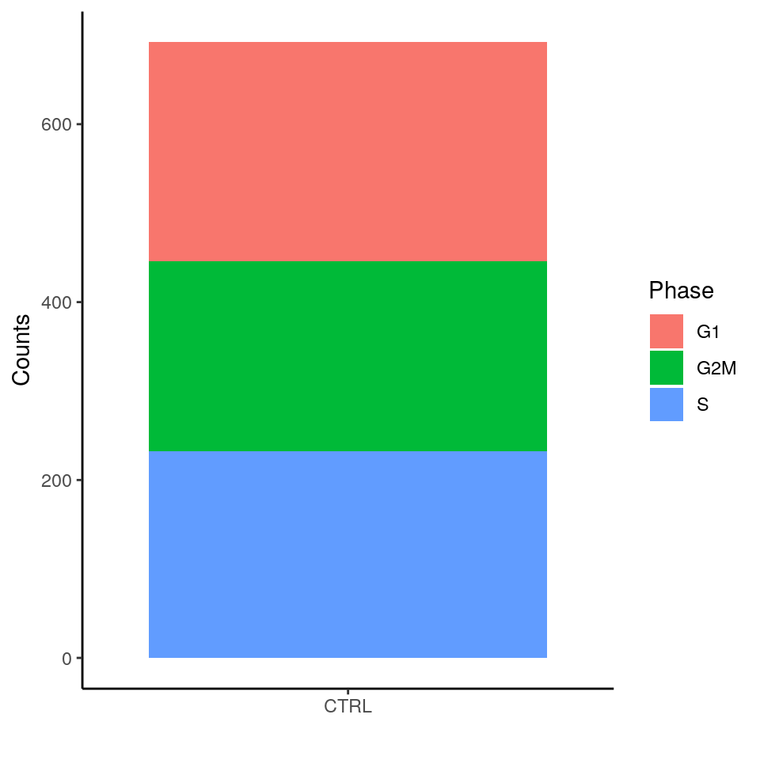

```r
library(ggplot2)
ggplot(yd_dat, aes(x = Var1, y = Freq, fill = Var2)) + geom_bar(stat = "identity",
    position = "stack") + labs(x = "", y = "Counts", fill = "Phase") + theme_classic()
```

# Regression and clustering

## Data normalization

```r
obj <- ScaleData(obj, vars.to.regress = c("percent.mt", "S.score", "G2M.score", "Phase"))
```

## Principle Component Analysis

```r
set.seed(1000)
obj <- RunPCA(obj, npcs = 30, verbose = FALSE)
```

## How many PCs? ~ Elbow Plot

- Elbow plots are useful to estimate number of PCs to take. You need to look for the *elbow* i.e. the point start were the curve turns flat. This approximation minimizes deviation and PC number.

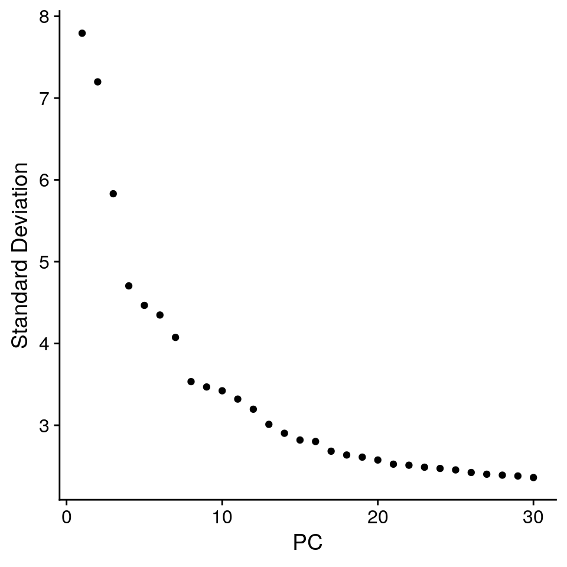

```r
ElbowPlot(obj, ndims = 30)
```

```r
#
numPC <- 15
```

## Clustering

```r
set.seed(1000)
maxPC <- numPC
obj <- FindNeighbors(obj, reduction = "pca", dims = 1:maxPC)
obj <- FindClusters(obj, resolution = 0.5)
```

```
## Modularity Optimizer version 1.3.0 by Ludo Waltman and Nees Jan van Eck
##
## Number of nodes: 692
## Number of edges: 21643
##
## Running Louvain algorithm...
## Maximum modularity in 10 random starts: 0.7679
## Number of communities: 7
## Elapsed time: 0 seconds
```

## Clustering

```r
obj <- RunUMAP(obj, reduction = "pca", dims = 1:maxPC)
obj <- RunTSNE(obj, reduction = "pca", dims = 1:maxPC)
```

## UMAP plot

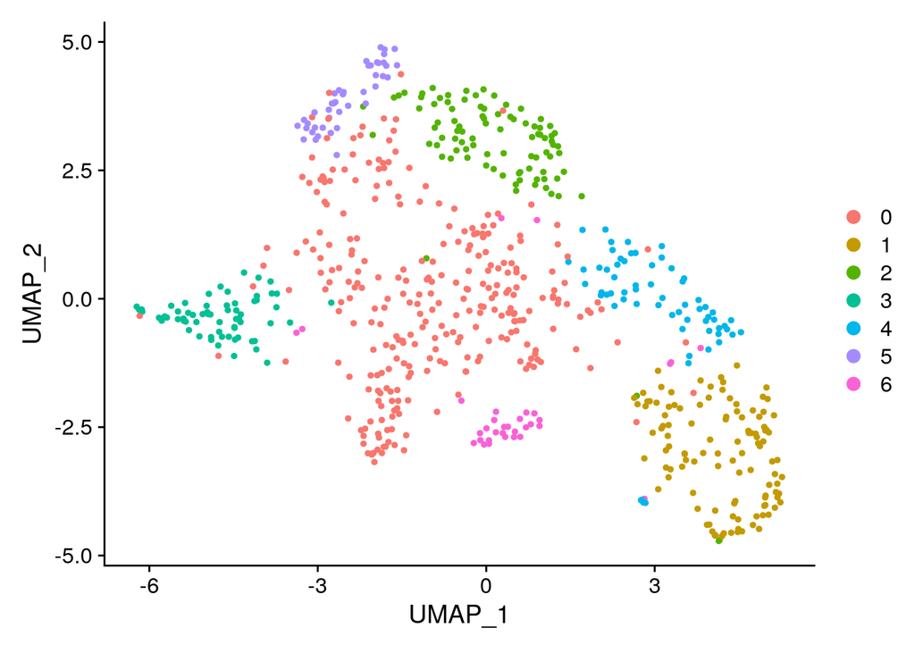

```r
DimPlot(obj, reduction = "umap")  # default it 'umap'
```

## tSNE plot

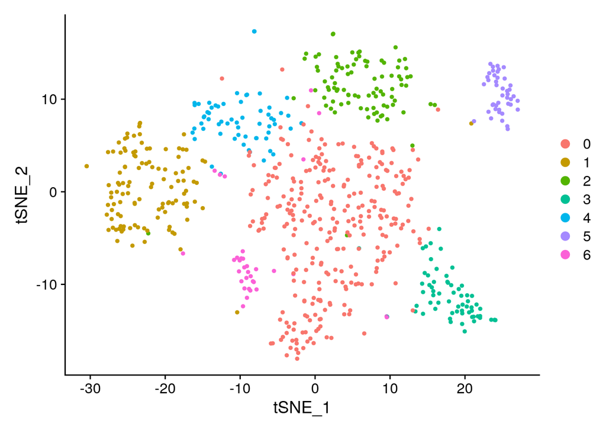

```r
DimPlot(obj, reduction = "tsne")
```

# Identify marker genes for each cluster

## Marker genes

```r
obj <- SetIdent(obj, value = "seurat_clusters")
clust.markers <- FindAllMarkers(obj, only.pos = TRUE, min.pct = 0.25, logfc.threshold = 0.25)
head(clust.markers)
```

```
##                  p_val avg_log2FC pct.1 pct.2    p_val_adj cluster      gene
## Igfbp2    5.690084e-29  0.8136702 0.820 0.403 8.255174e-25       0    Igfbp2
## Krt14     8.448994e-28  0.7369650 1.000 0.980 1.225780e-23       0     Krt14
## H19       2.916693e-26  0.7943296 0.972 0.785 4.231539e-22       0       H19
## Serpinb10 3.994589e-25  0.6534384 0.756 0.355 5.795350e-21       0 Serpinb10
## Fth1      4.408103e-22  0.4731999 1.000 0.936 6.395275e-18       0      Fth1
## Col17a1   1.542743e-21  0.6859089 0.845 0.511 2.238212e-17       0   Col17a1
```

## Select marker genes for each cluster

Here we will select the top 5 marker genes for each cluster.

```r
topG <- clust.markers %>%
    group_by(cluster) %>%
    top_n(n = 5, wt = avg_log2FC)
head(topG)
```

```
## # A tibble: 6 × 7
## # Groups:   cluster [2]
##      p_val avg_log2FC pct.1 pct.2 p_val_adj cluster gene
##      <dbl>      <dbl> <dbl> <dbl>     <dbl> <fct>   <chr>
## 1 5.69e-29      0.814 0.82  0.403  8.26e-25 0       Igfbp2
## 2 8.45e-28      0.737 1     0.98   1.23e-23 0       Krt14
## 3 2.92e-26      0.794 0.972 0.785  4.23e-22 0       H19
## 4 1.54e-21      0.686 0.845 0.511  2.24e-17 0       Col17a1
## 5 2.72e-17      0.655 0.728 0.452  3.94e-13 0       Cdkn1c
## 6 2.02e-80      1.76  0.833 0.076  2.93e-76 1       Sox9
```

# Advanced plots

## Dimplots ~ adjust point size

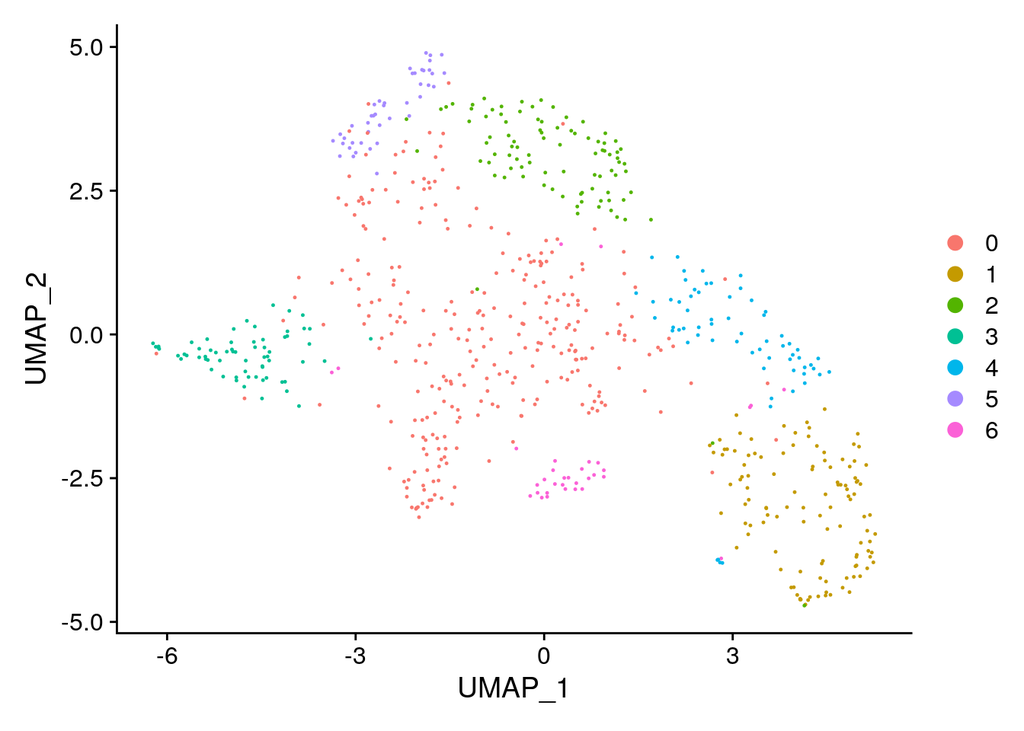

```r
DimPlot(obj, pt.size = 0.2)
```

## Dimplots with labeling clusters

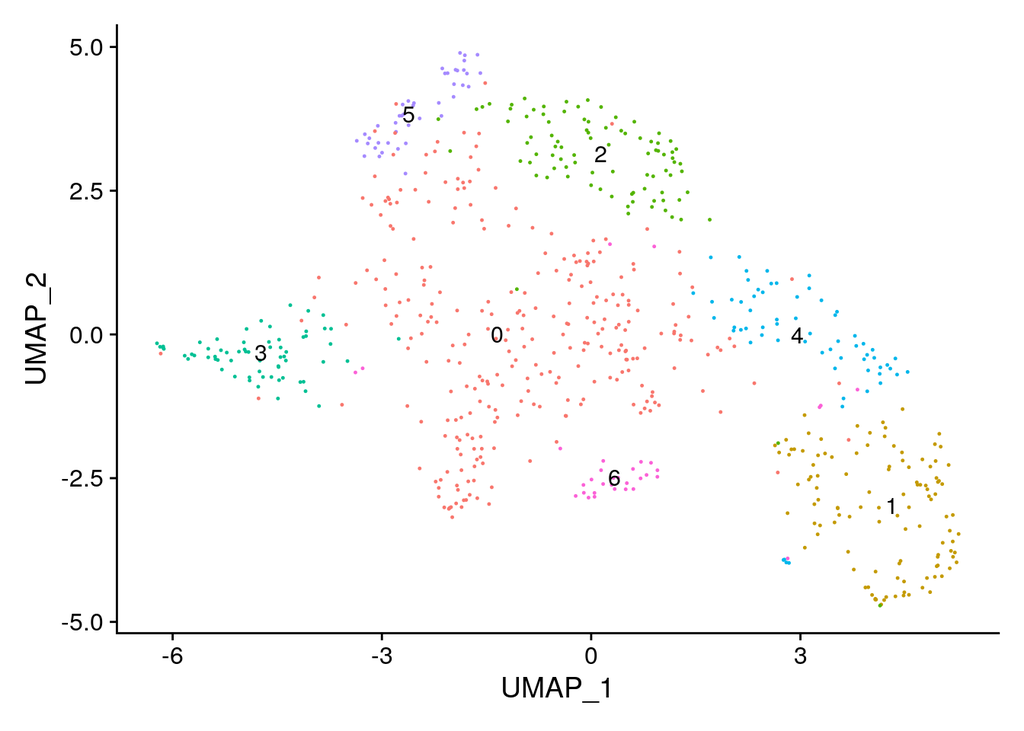

```r
DimPlot(obj, pt.size = 0.2, label = TRUE) + NoLegend()
```

## Marker Gene expression ~ heatmap

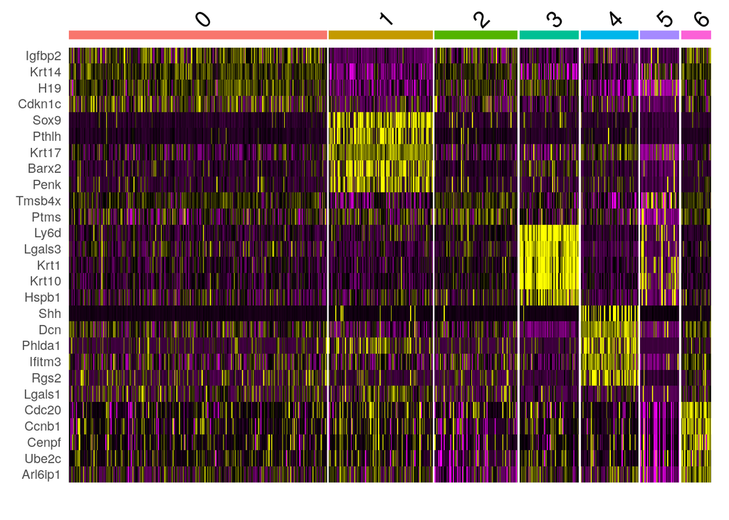

```r
DoHeatmap(obj, features = topG$gene) + NoLegend()
```

## Marker Gene Expression ~ FeaturePlot

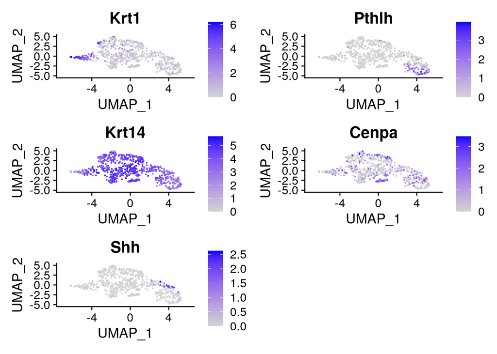

```r
gene_marker <- c("Krt1", "Pthlh", "Krt14", "Cenpa", "Shh")
FeaturePlot(obj, features = gene_marker, pt.size = 0.2)
```

## Marker Gene Expression ~ RidgePlot

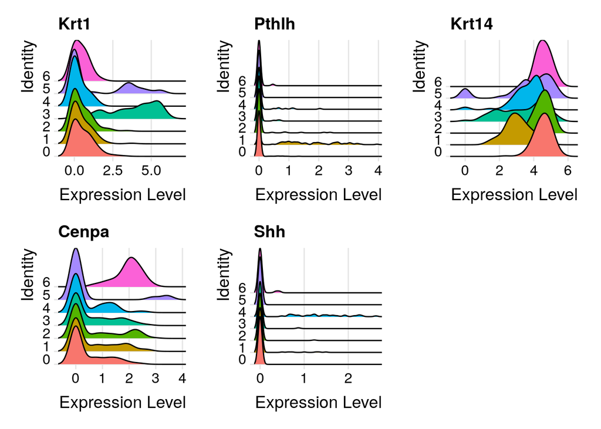

```r
RidgePlot(obj, features = gene_marker)
```

## Cell cycle phases by cluster

```r
tbl <- table(obj@meta.data$seurat_clusters, obj@meta.data$Phase)
tbl_dat <- as.data.frame(tbl)
to <- rowSums(tbl)
names(to) <- rownames(tbl)
tbl_dat$to <- to[match(names(to), tbl_dat$Var1)]
tbl_dat$prop <- tbl_dat$Freq/tbl_dat$to
tbl_dat[1:2, ]
```

```
##   Var1 Var2 Freq  to      prop
## 1    0   G1  134 283 0.4734982
## 2    1   G1   39 114 0.3421053
```

## Cell cycle phases by cluster ~ plot

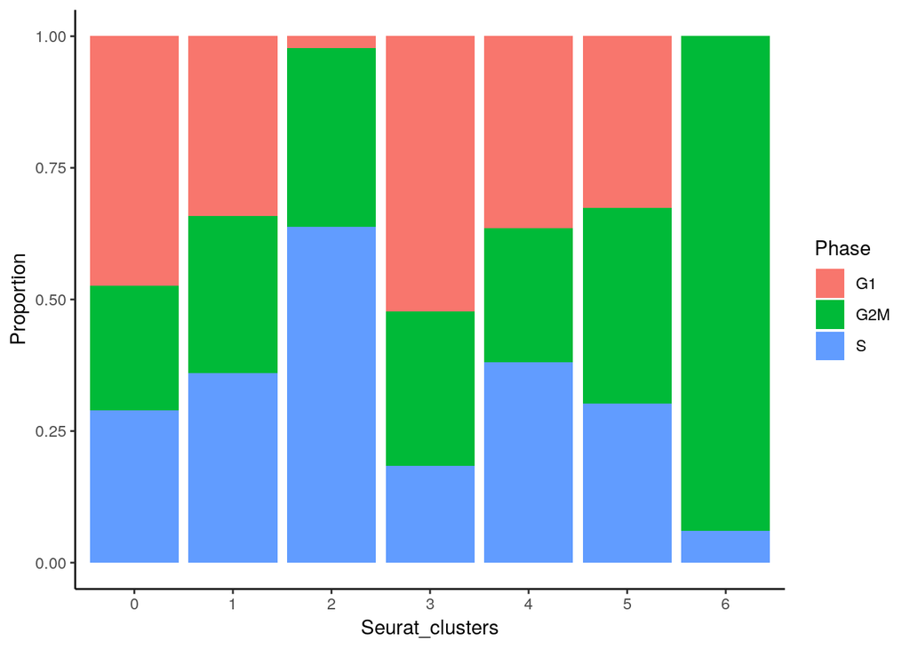

## Save file

```r
cellID <- rownames(obj@meta.data)[!obj@meta.data$seurat_clusters == 1]
obj_sub <- obj[, cellID]
saveRDS(obj_sub, "scSeq_Seurat_clean.rds")
```

## SeuratWrappers

- Seurat objects can be converted into different objects for further analysis with other tools i.e. Monocle or Velocity.
- For detailed information please refer to the Github repository for [SeuratWrappers](https://github.com/satijalab/seurat-wrappers).

## Time for an exercise!

Exercise on Seurat can be found here.

Answers can be found here.